# Charts from Consumer Complaints

[figure not shown]

[figure not shown]

### Chart 1: Number of Complaints per State

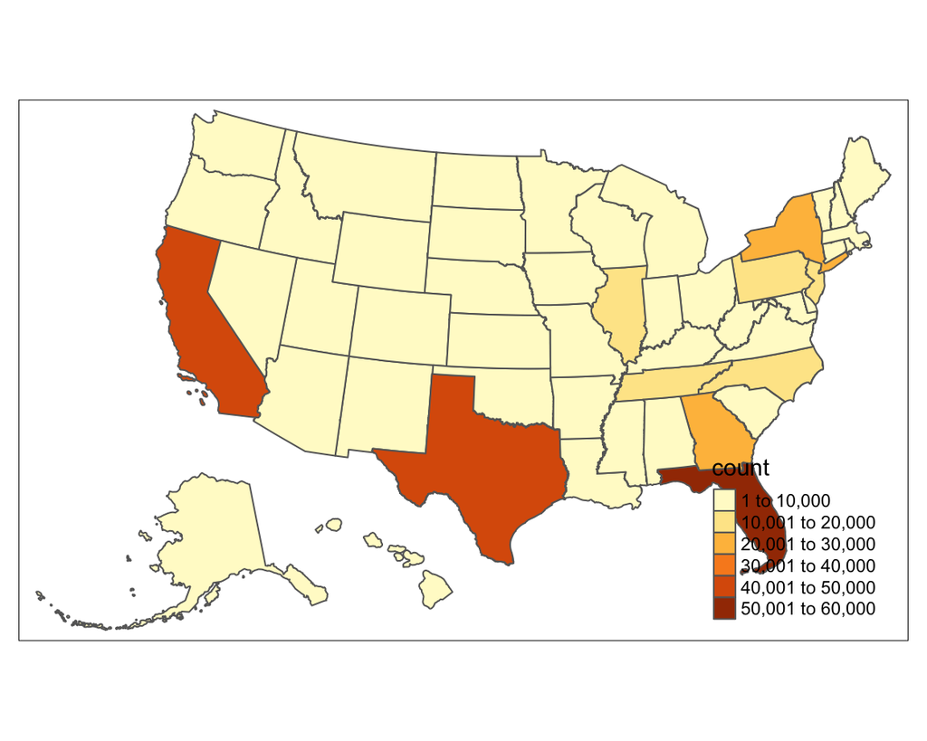

### Chart 2: Top 10 companies with the highest complaints

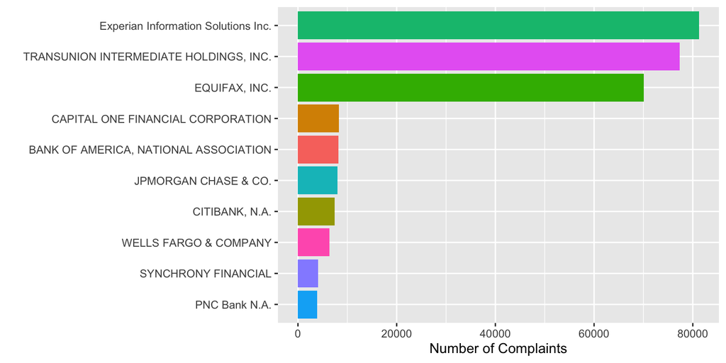

### Chart 3: Table of top 3 companies with the highest complaints

| Characteristic | Overall, N = 228,725 | EQUIFAX, INC., N = 70,075 | Experian Information Solutions Inc., N = 81,264 | TRANSUNION INTERMEDIATE HOLDINGS, INC., N = 77,386 |
| --- | --- | --- | --- | --- |
| yy_received, n/N (%) |  |  |  |  |
| 2020 | 228,725/228,725 (100%) | 70,075/70,075 (100%) | 81,264/81,264 (100%) | 77,386/77,386 (100%) |
| product, n/N (%) |  |  |  |  |
| Checking or savings account | 14/228,725 (<0.1%) | 3/70,075 (<0.1%) | 8/81,264 (<0.1%) | 3/77,386 (<0.1%) |
| Credit card or prepaid card | 161/228,725 (<0.1%) | 46/70,075 (<0.1%) | 58/81,264 (<0.1%) | 57/77,386 (<0.1%) |
| Credit reporting, credit repair services, or other personal consumer reports | 222,993/228,725 (97%) | 68,286/70,075 (97%) | 79,174/81,264 (97%) | 75,533/77,386 (98%) |
| Debt collection | 5,424/228,725 (2.4%) | 1,706/70,075 (2.4%) | 1,965/81,264 (2.4%) | 1,753/77,386 (2.3%) |
| Money transfer, virtual currency, or money service | 10/228,725 (<0.1%) | 3/70,075 (<0.1%) | 3/81,264 (<0.1%) | 4/77,386 (<0.1%) |
| Mortgage | 36/228,725 (<0.1%) | 17/70,075 (<0.1%) | 11/81,264 (<0.1%) | 8/77,386 (<0.1%) |
| Payday loan, title loan, or personal loan | 30/228,725 (<0.1%) | 5/70,075 (<0.1%) | 17/81,264 (<0.1%) | 8/77,386 (<0.1%) |
| Student loan | 16/228,725 (<0.1%) | 3/70,075 (<0.1%) | 6/81,264 (<0.1%) | 7/77,386 (<0.1%) |
| Vehicle loan or lease | 41/228,725 (<0.1%) | 6/70,075 (<0.1%) | 22/81,264 (<0.1%) | 13/77,386 (<0.1%) |
| consumer_consent_provided, n/N (%) |  |  |  |  |
|  | 13,316/228,725 (5.8%) | 11,333/70,075 (16%) | 120/81,264 (0.1%) | 1,863/77,386 (2.4%) |
| Consent not provided | 125,638/228,725 (55%) | 32,438/70,075 (46%) | 47,831/81,264 (59%) | 45,369/77,386 (59%) |
| Consent provided | 65,856/228,725 (29%) | 18,965/70,075 (27%) | 24,890/81,264 (31%) | 22,001/77,386 (28%) |
| Consent withdrawn | 267/228,725 (0.1%) | 92/70,075 (0.1%) | 99/81,264 (0.1%) | 76/77,386 (<0.1%) |
| N/A | 8,693/228,725 (3.8%) | 2,690/70,075 (3.8%) | 3,089/81,264 (3.8%) | 2,914/77,386 (3.8%) |
| Other | 14,955/228,725 (6.5%) | 4,557/70,075 (6.5%) | 5,235/81,264 (6.4%) | 5,163/77,386 (6.7%) |

### Chart 4: Line plot of complaints count over time for the company with the highest compaints

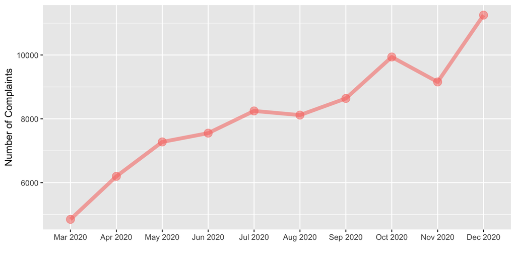

### About

**Description**

The *Complaints* dataset consists of 393,050 observations and 22 variables. The dataset includes complaints reported in 2020 for consumer financial services companies. Each complaint has been recorded with the date received, product, sub-product, issue, among other variables.

In order to investigate the *Complaints* dataset, we first wanted to visualize the total number of complaints per state (**Chart 1**). We were able to see that total number of complaints received by companies in Florida were the highest among other states with 50,449 complaints.

Next we wanted to identify the top 10 companies with the highest complaints, so we calculated the total number of complaints per company, and ranked them in a descending order (**Chart 2**). Experian Information Solutions Inc was the company with the highest complaints with 81,264 coming from 58 states.

Further, we wanted to understand the distribution of complaints among different products in the companies with the highest complaints, we generated a table of the top 3 companies with the highest complains(Experian Information Solutions Inc., TRANSUNION INTERMEDIATE HOLDINGS, INC., and EQUIFAX, INC.) which had total complaints of 81264, 77386, 70075 respectively (**Chart 3**). This table shows that most complaints for these three companies was for the following product: Credit reporting, credit repair services, or other personal consumer reports.

**Caveats**

While **Chart 3** showed that Credit reporting, credit repair services, or other personal consumer reports was the product with the highest complaints, investigating the specific sub-product within that category is still necessary to identify the main source of complaints and come up with strategies to fix the issue. Another caveat of our analysis is that **Chart 4** showed the number of complaints over time. However, we had to remove the month of January 2021 because it was incomplete and the data wouldn’t represent the whole month.